# dtu02417a1: Steady State Building Model

Edward J. Xu (Jie Xu), s181238

11th March, 2019

# Question 1.1

Read the 3h and the 6h data and plot the given quantities as a function of time. Do indicate which data is used for training and testing. Comment on the evolution of the values over time. It is OK if the plot is combined with results from the following questions.

```r
dat_3h <- read.csv("house_data_3h.csv")
time <- dat_3h[ , 1]
heating <- dat_3h[ , 2]
tempExternal <- dat_3h[ , 3]
iSolar <- dat_3h[ , 4]
series <- seq(1, length(time))
dat.f_3h <- data.frame(series, time, heating, tempExternal, iSolar)
n_3h <- length(dat.f_3h$series) - 8
```

```r
plot(dat.f_3h$series, dat.f_3h$heating,
     type = "b", col = "blue", lwd = 2, lty = 1, cex = 0.8,
     main = "Training and Testing Data of Heating in 3h Data", xlab = "Series", ylab = "W")
points(dat.f_3h$series[(n_3h+1):(n_3h+8)], dat.f_3h$heating[(n_3h+1):(n_3h+8)],
       col = "blue", lty = 1, pch = 16, cex = 0.8)
```

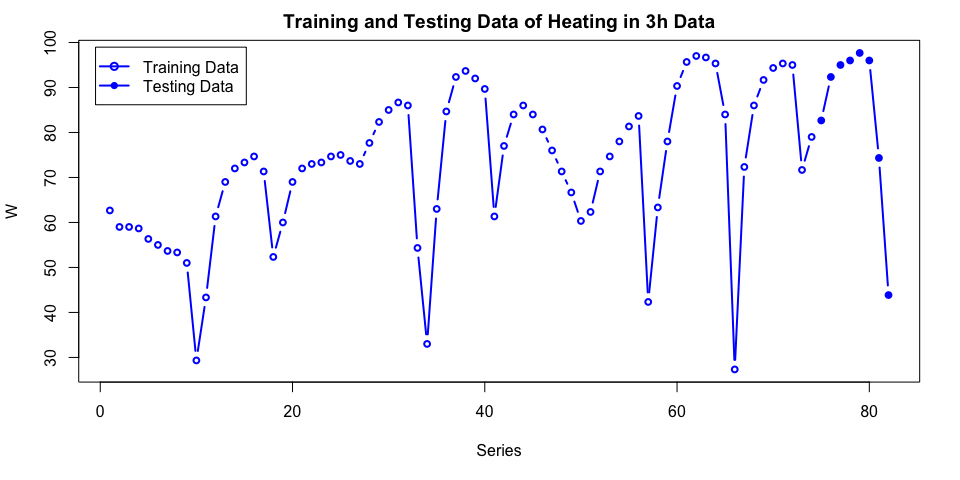

```r
legend("topleft", inset = .02, legend = c("Training Data", "Testing Data"), col = c("blue", "blue"),
       pch = c(1, 16), lty = c(1, 1), lwd = c(2, 2))
```

```r
plot(dat.f_3h$series, dat.f_3h$tempExternal,
     type = "b", col = "blue", lwd = 2, lty = 1, cex = 0.8,
     main = "Training and Testing Data of External Temperature in 3h Data", xlab = "Series", ylab = "Celsius Degree")
points(dat.f_3h$series[(n_3h+1):(n_3h+8)], dat.f_3h$tempExternal[(n_3h+1):(n_3h+8)],
       col = "blue", lty = 1, pch = 16, cex = 0.8)
```

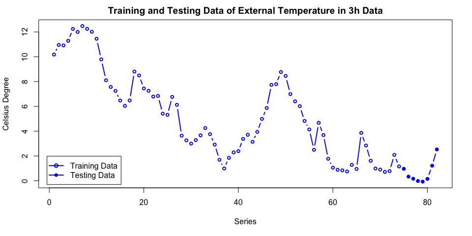

```r
legend("bottomleft", inset = .02, legend = c("Training Data", "Testing Data"), col = c("blue", "blue"),
       pch = c(1, 16), lty = c(1, 1), lwd = c(2, 2))
```

```r
plot(dat.f_3h$series, dat.f_3h$iSolar,
     type = "b", col = "blue", lwd = 2, lty = 1, cex = 0.8,
     main = "Training and Testing Data of Solar Irradiation in 3h Data", xlab = "Series", ylab = "W / m2")
points(dat.f_3h$series[(n_3h+1):(n_3h+8)], dat.f_3h$iSolar[(n_3h+1):(n_3h+8)],
       col = "blue", lty = 1, pch = 16, cex = 0.8)
```

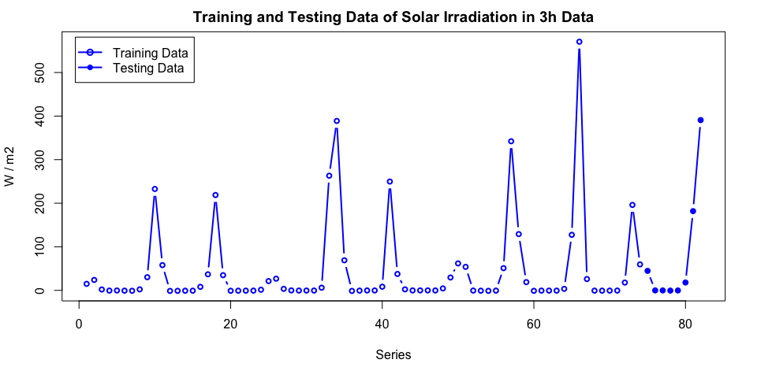

```r
legend("topleft", inset = .02, legend = c("Training Data", "Testing Data"), col = c("blue", "blue"),
       pch = c(1, 16), lty = c(1, 1), lwd = c(2, 2))
```

```r
dat_6h <- read.csv("house_data_6h.csv")
time <- dat_6h[ , 1]
heating <- dat_6h[ , 2]
tempExternal <- dat_6h[, 3]
iSolar <- dat_6h[ , 4]
series <- seq(1, length(time))
dat.f_6h <- data.frame(series, time, heating, tempExternal, iSolar)
n_6h <- length(dat.f_6h$series) - 4
```

```r
plot(dat.f_6h$series, dat.f_6h$heating,
     type = "b", col = "blue", lwd = 2, lty = 1, cex = 0.8,
     main = "Training and Testing Data of Heating in 6h Data", xlab = "Series", ylab = "W")
points(dat.f_6h$series[(n_6h+1):(n_6h+8)], dat.f_6h$heating[(n_6h+1):(n_6h+8)],
       col = "blue", lty = 1, pch = 16, cex = 0.8)
```

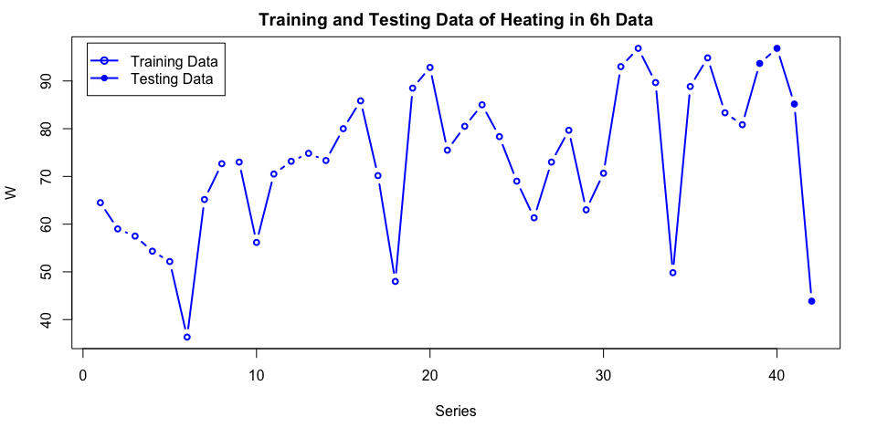

```r
legend("topleft", inset = .02, legend = c("Training Data", "Testing Data"), col = c("blue", "blue"),
       pch = c(1, 16), lty = c(1, 1), lwd = c(2, 2))
```

```r
plot(dat.f_6h$series, dat.f_6h$tempExternal,
     type = "b", col = "blue", lwd = 2, lty = 1, cex = 0.8,
     main = "Training and Testing Data of External Temperature in 6h Data", xlab = "Series", ylab = "Celsius Degree")
points(dat.f_6h$series[(n_6h+1):(n_6h+8)], dat.f_6h$tempExternal[(n_6h+1):(n_6h+8)],
       col = "blue", lty = 1, pch = 16, cex = 0.8)
```

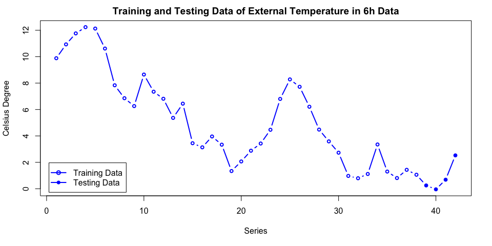

```r
legend("bottomleft", inset = .02, legend = c("Training Data", "Testing Data"), col = c("blue", "blue"),
       pch = c(1, 16), lty = c(1, 1), lwd = c(2, 2))
```

```r
plot(dat.f_6h$series, dat.f_6h$iSolar,
     type = "b", col = "blue", lwd = 2, lty = 1, cex = 0.8,
     main = "Training and Testing Data of Solar Irradiation in 6h Data", xlab = "Series", ylab = "W / m2")
points(dat.f_6h$series[(n_6h+1):(n_6h+8)], dat.f_6h$iSolar[(n_6h+1):(n_6h+8)],
       col = "blue", lty = 1, pch = 16, cex = 0.8)
```

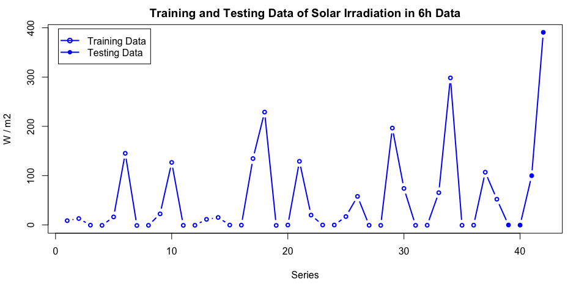

```r
legend("topleft", inset = .02, legend = c("Training Data", "Testing Data"), col = c("blue", "blue"),
       pch = c(1, 16), lty = c(1, 1), lwd = c(2, 2))
```

# Question 1.2

The observations in the last 24 hours are kept only for comparisons, so they are not in the training data set.

## Define functions for General Linear Model (GLM)

```r
# ----------------------------------------------------------------------------------------------------------------------
cal_vec_sse.hat <- function(mat_x, vec_y, vec_theta.hat, mat_capSigma = diag(length(mat_x[,1]))){
    # Calculate the sum of squared error (sse), eq.
    vec_epsilon <- vec_y - mat_x %*% vec_theta.hat
    sse.hat <- t(vec_epsilon) %*% solve(mat_capSigma) %*% vec_epsilon
    return(sse.hat)
}
cal_sigma.hat <- function(mat_x, vec_y, vec_theta.hat, mat_capSigma = diag(length(mat_x[,1]))){
    # Estimator for the variance, eq 3.44, Theorem 3.4, P39
    sigma.hat.square <- cal_vec_sse.hat(mat_x, vec_y, vec_theta.hat, mat_capSigma) /
                        (length(mat_x[,1]) - length(vec_theta.hat))
    sigma.hat <- sqrt(drop(sigma.hat.square))
    return(sigma.hat)
}
cal_mat_var.theta.hat <- function(mat_x, sigma.hat, mat_capSigma= diag(length(mat_x[,1]))){
    # Calculate the variance of vec_theta.hat, eq 3.43, P39
    mat_var.theta.hat <- sigma.hat^2 * solve(t(mat_x) %*% solve(mat_capSigma) %*% mat_x)
    return(drop(mat_var.theta.hat))
}
cal_mat_intervalConf <- function(prob = 0.95, mat_x, vec_theta.hat, vec_y){
    n <- length(mat_x[,1])
    p <- length(vec_theta.hat)
    quantileStudentDist <- qt(p = prob, df = n - p)
    vec_var.y.hat <- (vec_y - mat_x %*% vec_theta.hat)^2
    vec_boundUp <- mat_x %*% vec_theta.hat + quantileStudentDist * sqrt(vec_var.y.hat / n)
    vec_boundLow <- mat_x %*% vec_theta.hat - quantileStudentDist * sqrt(vec_var.y.hat / n)
    return(list(vec_boundUp = vec_boundUp, vec_boundLow = vec_boundLow))
}
```

## Define functions of weighted least square estimation, with default “mat_capSigma” being identity matrix.

```r
pred_vec_theta.hat <- function(mat_x, vec_y, mat_capSigma = diag(length(mat_x[,1]))){
    vec_theta.hat <- solve(t(mat_x) %*% solve(mat_capSigma) %*% mat_x) %*% t(mat_x) %*% solve(mat_capSigma) %*% vec_y
    return(vec_theta.hat)
}
```

## 1.2.1

Formulate a linear regression model to estimate theta, in which it is assumed that the residuals have a constant variance and are independent. Estimate the parameters using the 6h data and include a measure of uncertainty for each of the estimates.

```r
mat_x_6h <- cbind(1, dat.f_6h$tempExternal[1:n_6h], dat.f_6h$iSolar[1:n_6h])
vec_y_6h <- dat.f_6h$heating[1:n_6h]
vec_theta.hat_ols_6h <- pred_vec_theta.hat(mat_x = mat_x_6h, vec_y = vec_y_6h)
sigma.hat_ols_6h <- cal_sigma.hat(mat_x = mat_x_6h, vec_theta.hat = vec_theta.hat_ols_6h, vec_y = vec_y_6h)
mat_var.theta.hat_ols_6h <- cal_mat_var.theta.hat(mat_x = mat_x_6h, sigma = sigma.hat_ols_6h)
tempInternal_ols_6h <- vec_theta.hat_ols_6h[1] / - vec_theta.hat_ols_6h[2]
tempInternal_ols_6h
```

```
[1] 28.29711
```

Plot the residuals for this model.

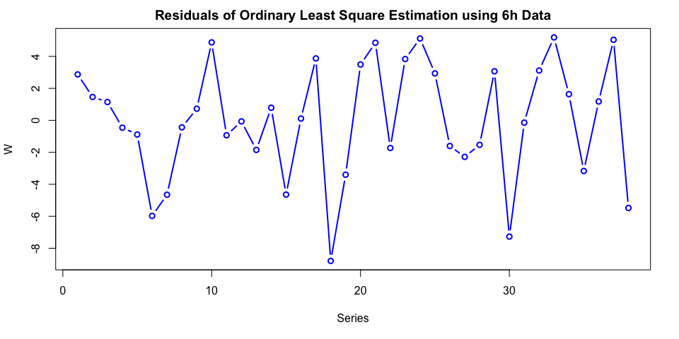

```r
vec_epsilon_ols_6h <- vec_y_6h - mat_x_6h %*% vec_theta.hat_ols_6h
plot(dat.f_6h$series[1:n_6h], vec_epsilon_ols_6h, type = "b", col = "blue", lwd = 2,
     main = "Residuals of Ordinary Least Square Estimation using 6h Data", xlab = "Series", ylab = "W")
```

Estimate the parameters using the 3h data and include a measure of uncertainty for each of the estimates.

```r
mat_x_3h <- cbind(1, dat.f_3h$tempExternal[1:n_3h], dat.f_3h$iSolar[1:n_3h])
vec_y_3h <- dat.f_3h$heating[1:n_3h]
vec_theta.hat_ols_3h <- pred_vec_theta.hat(mat_x = mat_x_3h, vec_y = vec_y_3h)
sigma.hat_ols_3h <- cal_sigma.hat(mat_x = mat_x_3h, vec_theta.hat = vec_theta.hat_ols_3h, vec_y = vec_y_3h)
mat_var.theta.hat_ols_3h <- cal_mat_var.theta.hat(mat_x = mat_x_3h, sigma = sigma.hat_ols_3h)
tempInternal_ols_3h <- vec_theta.hat_ols_3h[1] / - vec_theta.hat_ols_3h[2]
tempInternal_ols_3h
```

```
[1] 28.32177
```

Plot the residuals for this model.

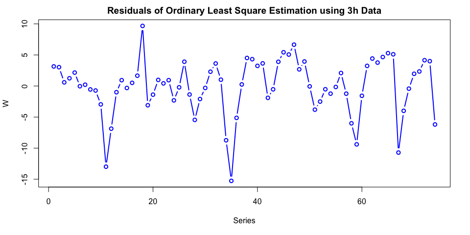

```r
vec_epsilon_ols_3h <- vec_y_3h - mat_x_3h %*% vec_theta.hat_ols_3h
plot(dat.f_3h$series[1:n_3h], vec_epsilon_ols_3h, type = "b", col = "blue", lwd = 2,
     main = "Residuals of Ordinary Least Square Estimation using 3h Data", xlab = "Series", ylab = "W")
```

## 1.2.2

Now, we assume that the correlation structure of the residiuals is an exponential decaying function of the time distance between two observations, define the relaxation algorithm:

```r
do_mat_capSigma_expDecay <- function(rho, n){
    mat_capSigma <- diag(n)
    for (i in 1: n){
        for (j in 1: n){
            mat_capSigma[i, j] <- rho^(abs(i - j))
        }
    }
    return(mat_capSigma)
}
do_newRho <- function(mat_x, vec_epsilon, sigma, n){
    sum <- 0
    for (i in 1: (n - 1)){
        sum <- sum + vec_epsilon[i] * vec_epsilon[i+1]
    }
    rho <- sum / (sigma^2 * (n - 1))
    return(rho)
}
cal_rho_expDecayRelaxAlgo <- function(mat_x, vec_y){
    rho <- 0
    n <- length(mat_x[,1])
    for (t in 1: 5){
        mat_capSigma <- do_mat_capSigma_expDecay(rho, n)
        vec_theta.hat <- pred_vec_theta.hat(mat_x, vec_y, mat_capSigma)
        sigma.hat <- cal_sigma.hat(mat_x, vec_y, vec_theta.hat)
        vec_epsilon <- vec_y - mat_x %*% vec_theta.hat
        rho <- do_newRho(mat_x, vec_epsilon, sigma.hat, n)
    }
    return(rho)
}
```

```r
(rho_expDecay_6h <- cal_rho_expDecayRelaxAlgo(mat_x = mat_x_6h, vec_y = vec_y_6h))
```

```
[1] 0.05331725
```

```r
mat_capSigma_expDecay_6h <- do_mat_capSigma_expDecay(rho = rho_expDecay_6h,
                                                                 n = n_6h)
vec_theta.hat_expDecay_6h <- pred_vec_theta.hat(mat_x = mat_x_6h, vec_y = vec_y_6h,
                                        mat_capSigma = mat_capSigma_expDecay_6h)
sigma.hat_expDecay_6h <- cal_sigma.hat(mat_x = mat_x_6h, vec_theta.hat = vec_theta.hat_expDecay_6h, vec_y = vec_y_6h)
mat_var.theta.hat_expDecay_6h <- cal_mat_var.theta.hat(mat_x = mat_x_6h, sigma = sigma.hat_expDecay_6h)
(tempInternal_expDecay_6h <- vec_theta.hat_expDecay_6h[1] / - vec_theta.hat_expDecay_6h[2])
```

```
[1] 28.36691
```

```r
vec_epsilon_expDecay_6h <- vec_y_6h - mat_x_6h %*% vec_theta.hat_expDecay_6h
plot(dat.f_6h$series[1:n_6h], vec_epsilon_expDecay_6h,
     type = "l", col = "red", lwd = 3,
     main = "Comparison of Residuals from OLS and WLS(Exp Decay) using 6h Data", xlab = "Series", ylab = "W")
lines(dat.f_6h$series[1:n_6h], vec_epsilon_ols_6h,
      type = "l", col = "blue", lty = 2, lwd = 2)
```

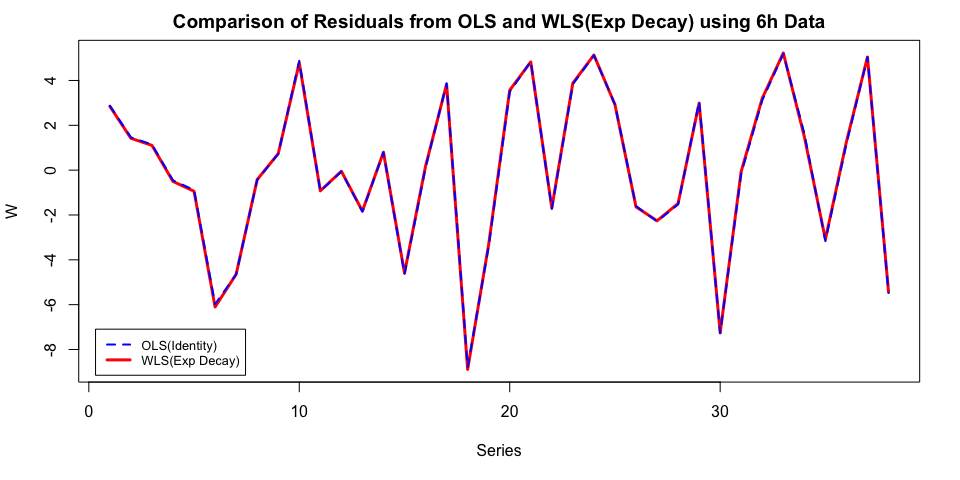

```r
legend("bottomleft", inset = .02, legend = c("OLS(Identity)", "WLS(Exp Decay)"), col = c("blue", "red"),
       lty = c(2, 1), lwd = c(2, 3), cex= 0.8)
```

| capSigma | rho | theta1.hat | theta2.hat | theta3.hat | sigma.hat | tempInternal |
| --- | --- | --- | --- | --- | --- | --- |
| Sigma being Identity Matrixt | 0.0000000 | 96.34049 | -3.404605 | -0.1231323 | 3.748241 | 28.29711 |
| Sigma with Exp Decaying | 0.0533173 | 96.24318 | -3.392797 | -0.1224553 | 3.748756 | 28.36691 |

## 1.2.3

```r
(rho_expDecay_3h <- cal_rho_expDecayRelaxAlgo(mat_x = mat_x_3h, vec_y = vec_y_3h))
```

```
[1] 0.5564169
```

```r
mat_capSigma_expDecay_3h <- do_mat_capSigma_expDecay(rho = rho_expDecay_3h,
                                                                 n = n_3h)
vec_theta.hat_expDecay_3h <- pred_vec_theta.hat(mat_x = mat_x_3h, vec_y = vec_y_3h,
                                   mat_capSigma = mat_capSigma_expDecay_3h)
sigma.hat_expDecay_3h <- cal_sigma.hat(mat_x = mat_x_3h, vec_y = vec_y_3h, vec_theta.hat = vec_theta.hat_expDecay_3h)
mat_var.theta.hat_expDecay_3h <- cal_mat_var.theta.hat(mat_x = mat_x_3h, sigma = sigma.hat_expDecay_3h)
(tempInternal_expDecay_3h <- vec_theta.hat_expDecay_3h[1] / - vec_theta.hat_expDecay_3h[2])
```

```
[1] 28.87185
```

```r
vec_epsilon_expDecay_3h <- vec_y_3h - mat_x_3h %*% vec_theta.hat_expDecay_3h
plot(dat.f_3h$series[1:n_3h], vec_epsilon_expDecay_3h,
     type = "l", col = "red", lwd = 3,
     main = "Comparison of Residuals from OLS and WLS(Exp Decay) using 3h Data", xlab = "Series", ylab = "W")
lines(dat.f_3h$series[1:n_3h], vec_epsilon_ols_3h,
      type = "l", col = "blue", lty = 2, lwd = 2)
```

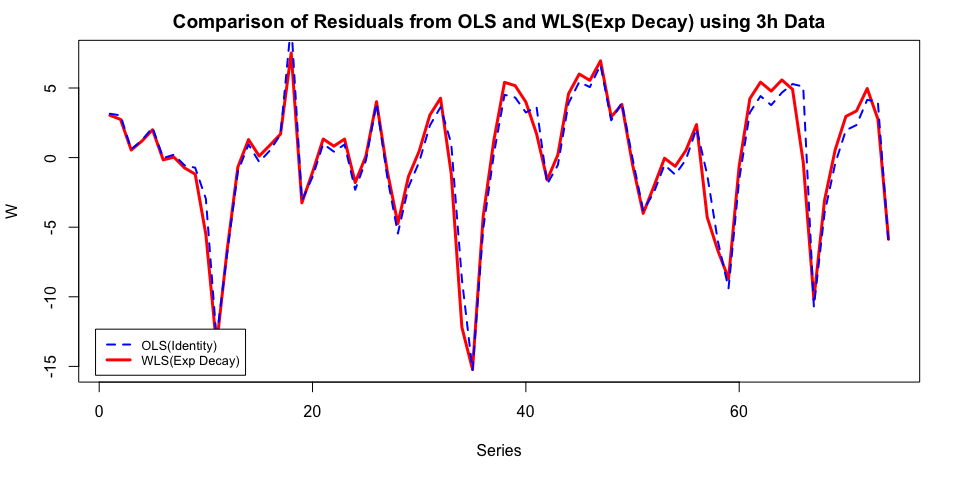

```r
legend("bottomleft", inset = .02, legend = c("OLS(Identity)", "WLS(Exp Decay)"), col = c("blue", "red"),
       lty = c(2, 1), lwd = c(2, 3), cex= 0.8)
```

| capSigma | rho | theta1.hat | theta2.hat | theta3.hat | sigma.hat | tempInternal |
| --- | --- | --- | --- | --- | --- | --- |
| Sigma being Identity Matrixt | 0.0000000 | 95.34499 | -3.366492 | -0.1053378 | 4.543622 | 28.32177 |
| Sigma with Exp Decaying | 0.5564169 | 94.26587 | -3.264975 | -0.0946527 | 4.688327 | 28.87185 |

# Question 3, Local Trend mode

## 3.1, Local Linear Trend Model

Define functions for trend model.

```r
do_seq_zeroDecreaseRev <- function(n){return(rev(- seq(0, n-1)))}
do_mat_capSigma_trend <- function(lambda = 1, n){
    mat_capSigma_trend <- diag(n)
    seq_zdi <- do_seq_zeroDecreaseRev(n)
    for (i in 1: n){
        mat_capSigma_trend[i, i] <- 1 * lambda^seq_zdi[i]
    }
    return(mat_capSigma_trend)
}
cal_mat_capF_trend <- function(mat_x_trend, mat_capSigma_trend){
    mat_capF <- t(mat_x_trend) %*% solve(mat_capSigma_trend) %*% mat_x_trend
    return(mat_capF)
}
cal_vec_h_trend <- function(mat_x_trend, mat_capSigma_trend, vec_y_trend){
    mat_h <- t(mat_x_trend) %*% solve(mat_capSigma_trend) %*% vec_y_trend
    return(mat_h)
}
cal_vec_theta.hat_trend <- function(mat_x_trend, mat_capSigma_trend, vec_y_trend){
    mat_capF <- cal_mat_capF_trend(mat_x_trend, mat_capSigma_trend)
    mat_h <- cal_vec_h_trend(mat_x_trend, mat_capSigma_trend, vec_y_trend)
    vec_theta.hat_trend <- solve(mat_capF) %*% mat_h
    return(vec_theta.hat_trend)
}
cal_vec_intervalPred <- function(prob = 0.95, n, p, y.hat, var){
    quantileStudentDist <- qt(p = 0.95, df = n - p)
    boundUp <- y.hat + quantileStudentDist * sqrt(var)
    boundLow <- y.hat - quantileStudentDist * sqrt(var)
    return(list(boundUp = drop(boundUp), boundLow = drop(boundLow)))
}
cal_mat_intervalPred <- function(vec_l, prob = 0.95, n, p, vec_y.hat, vec_var){
    vec_boundUp <- numeric(length(vec_l))
    vec_boundLow <- numeric(length(vec_l))
    for (i in seq(1, length(vec_l))){
        interval <- cal_vec_intervalPred(prob, n, p, y.hat = vec_y.hat[i], var = vec_var[i])
        vec_boundUp[i] <- interval$boundUp
        vec_boundLow[i] <- interval$boundLow
    }
    return(list(vec_boundUp = vec_boundUp, vec_boundLow = vec_boundLow))
}
cal_vec_memoryTotal <- function(lambda, n){
    vec_memoryTotal <- numeric(n)
    vec_memoryTotal[1] <- 1
    for (j in 1: (n-1)){
     vec_memoryTotal[j+1] <- vec_memoryTotal[j] + lambda^j
    }
    return(vec_memoryTotal)
}
```

Convergence of Total Memory of Local Trend Model

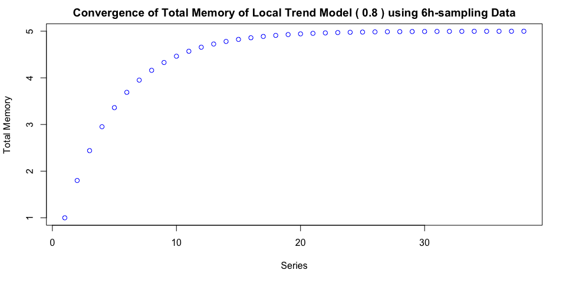

```r
n_trendL_1_6h <- n_6h
lambda_trendL_1_6h <- 0.8
vec_memoryTotal_1_6h <- cal_vec_memoryTotal(lambda= lambda_trendL_1_6h, n = n_trendL_1_6h)
plot(seq(1, n_trendL_1_6h), vec_memoryTotal_1_6h, col = "blue",
     main = paste("Convergence of Total Memory of Local Trend Model (", lambda_trendL_1_6h,
                  ") using 6h-sampling Data"),
     xlab = "Series", ylab = "Total Memory")
```

Define Functions for Linear Trend Model

Use a local linear trend model on the outdoor temperature in the 6h training data using lambda = 0.8.

y = theta0 + theta1 * j + epsilon

Plot the training data and the corresponding one step predictions for all observations in the training data.

```r
func_f_linear <- function(j){
    return(rbind(1, j))
}
pred_y_trend_linear <- function(l, vec_theta.hat_trend){
    y_pred_trend <- t(func_f_linear(l)) %*% vec_theta.hat_trend
    return(y_pred_trend)
}
pred_var_trend_linear <- function(l, mat_x_trend, vec_y_trend, vec_theta.hat_trend, mat_capSigma_trend){
    sigma.hat <- cal_sigma.hat(mat_x = mat_x_trend, vec_y = vec_y_trend,
                           vec_theta.hat = vec_theta.hat_trend, mat_capSigma = mat_capSigma_trend)
    mat_capF_trend_trend <- cal_mat_capF_trend(mat_x_trend, mat_capSigma_trend)
    var_pred_trend <- sigma.hat^2 %*% (1 + t(func_f_linear(l)) %*% solve(mat_capF_trend_trend) %*% func_f_linear(l))
    return(var_pred_trend)
}
pred_vec_y_trend_linear <- function(vec_l, vec_theta.hat_trend){
    vec_y_trend_linear <- numeric(length(vec_l))
    for (i in (1: length(vec_l))){
        vec_y_trend_linear[i] <- pred_y_trend_linear(vec_l[i], vec_theta.hat_trend)
    }
    return(vec_y_trend_linear)
}
pred_vec_var_trend_linear <- function(vec_l, mat_x_trend, vec_y.pred_trend, vec_theta.hat_trend, mat_capSigma_trend){
    vec_var_trend_linear <- numeric(length(vec_l))
    for (i in (1: length(vec_l))){
        vec_var_trend_linear[i] <- pred_var_trend_linear(vec_l[i], mat_x_trend,
                                                         vec_y.pred_trend[i], vec_theta.hat_trend, mat_capSigma_trend)
    }
    return(vec_var_trend_linear)
}
```

### 1.3.1.1 Estimation

Estimation

```r
mat_capSigma_trendL_1_6h <- do_mat_capSigma_trend(lambda = lambda_trendL_1_6h, n = n_trendL_1_6h)
vec_y_trendL_1_6h <- dat.f_6h$tempExternal[1:n_6h]
seq_zdi_trendL_1_6h <- do_seq_zeroDecreaseRev(n_trendL_1_6h)
mat_x_trendL_1_6h <- cbind(1, seq_zdi_trendL_1_6h)
vec_theta.hat_trendL_1_6h <- cal_vec_theta.hat_trend(mat_x_trend = mat_x_trendL_1_6h,
                                           mat_capSigma_trend = mat_capSigma_trendL_1_6h,
                                           vec_y_trend = vec_y_trendL_1_6h)
cal_mat_capF_trend(mat_x_trend = mat_x_trendL_1_6h,
                   mat_capSigma_trend = mat_capSigma_trendL_1_6h)
```

```
                               seq_zdi_trendL_1_6h
                      4.998962           -19.95638
seq_zdi_trendL_1_6h -19.956385           178.14739
```

```r
cal_vec_h_trend(mat_x_trend = mat_x_trendL_1_6h,
                mat_capSigma_trend = mat_capSigma_trendL_1_6h,
                vec_y_trend = vec_y_trendL_1_6h)
```

```
                          [,1]
                      9.437496
seq_zdi_trendL_1_6h -62.490852
```

```r
sigma.hat_trendL_1_6h <- cal_sigma.hat(mat_x = mat_x_trendL_1_6h, vec_y = vec_y_trendL_1_6h,
                                       vec_theta.hat = vec_theta.hat_trendL_1_6h,
                                       mat_capSigma = mat_capSigma_trendL_1_6h)
mat_var.theta.hat_trendL_1_6h <- cal_mat_var.theta.hat(mat_x = mat_x_trendL_1_6h, sigma.hat = sigma.hat_trendL_1_6h,
                                                       mat_capSigma = mat_capSigma_trendL_1_6h)
```

### 1.3.1.2 Prediction

```r
vec_y.hat_trendL_1_6h <- mat_x_trendL_1_6h %*% vec_theta.hat_trendL_1_6h
vec_l_trendL_1_6h <- c(1, 2, 3, 4)
vec_y.pred_trendL_1_6h <- pred_vec_y_trend_linear(vec_l = vec_l_trendL_1_6h,
                                                     vec_theta.hat_trend = vec_theta.hat_trendL_1_6h)
vec_var.pred_trendL_1_6h <- pred_vec_var_trend_linear(vec_l = vec_l_trendL_1_6h,
                                                         mat_x_trend = mat_x_trendL_1_6h,
                                                         mat_capSigma_trend = mat_capSigma_trendL_1_6h,
                                                         vec_y.pred_trend = vec_y.pred_trendL_1_6h,
                                                         vec_theta.hat_trend = vec_theta.hat_trendL_1_6h)
mat_intervaPred_trendL_1_6h <- cal_mat_intervalPred(vec_l = vec_l_trendL_1_6h, prob = 0.95,
                                                    n = n_trendL_1_6h, p = length(vec_theta.hat_trendL_1_6h),
                                                    vec_y.hat = vec_y.pred_trendL_1_6h,
                                                    vec_var = vec_var.pred_trendL_1_6h)
```

### 1.3.1.4

```r
plot(dat.f_6h$series[1:n_6h], dat.f_6h$tempExternal[1:n_6h],
     type = "b", col = "blue", lwd = 1, lty = 1, xlim = c(0, n_6h + 4), ylim = c(-4, 12),
     main = paste("Prediction of External Temperature by Linear Local Trend Model (", lambda_trendL_1_6h,
                  ") using 6h Data"),
     xlab = "Series", ylab = "Celsius Degree")
points(n_trendL_1_6h + seq(4), dat.f_6h$tempExternal[(n_trendL_1_6h+1): (n_trendL_1_6h+4)],
       type = "b", col = "blue", lty = 1, pch = 16)
```

```r
lines(dat.f_6h$series[(n_6h):(n_6h+1)], dat.f_6h$tempExternal[(n_6h):(n_6h+1)],
      type = "c", col = "blue", lty = 1)
legend("bottomleft", inset = .02, legend = c("Training Data", "Testing Data", "Trend Model",
                                             "Prediction", "Pred Interval"),
       col = c("blue", "blue", "red", "red", "red"), pch = c(1, 16, NA, 15, 6),
       lty = c(1, 1, 2, 3, 1), lwd = c(1, 1, 3, 3, 1))
```

```r
# Plot the validation result
lines(dat.f_6h$series[1:n_6h], vec_y.hat_trendL_1_6h,
      type = "l", col = "red", lty = 2, lwd = 3)
# Plot the prediction result
points(n_trendL_1_6h + vec_l_trendL_1_6h, vec_y.pred_trendL_1_6h,
       type = "b", col = "red", pch = 15, lty = 3, lwd = 2)
```

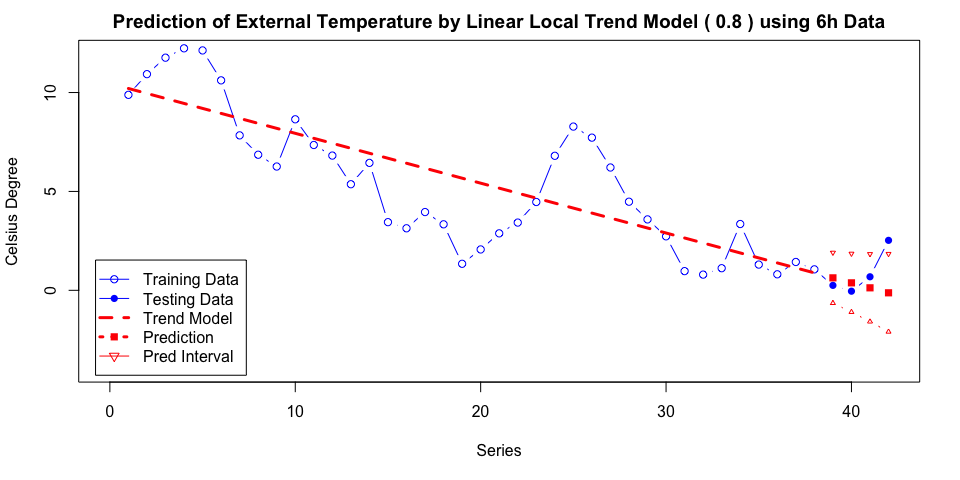

```r
lines(n_trendL_1_6h + vec_l_trendL_1_6h, mat_intervaPred_trendL_1_6h$vec_boundUp,
      type = "b", col = 'red', lwd = 1, lty = 1, pch = 6, cex= 0.5)
lines(n_trendL_1_6h + vec_l_trendL_1_6h, mat_intervaPred_trendL_1_6h$vec_boundLow,
      type = "b", col = 'red', lwd = 1, lty = 1, pch = 2, cex= 0.5)
```

## 3.2, Quadratic Local Trend Model (lambda = 0.8) of 6h-sampling Data

y = theta0 + theta1 * j + theta2 * j^2/2 + epsilon

Define Functions for Quadratic Local Trend Model

```r
func_f_quadratic <- function(j){
    return(rbind(1, j, j^2 / 2))
}
pred_y_trend_quadratic <- function(l, vec_theta.hat_trend){
    y_pred_trend <- t(func_f_quadratic(l)) %*% vec_theta.hat_trend
    return(y_pred_trend)
}
pred_vec_y_trend_quadratic <- function(vec_l, vec_theta.hat_trend){
    vec_y.pred_trend_quadratic <- numeric(length(vec_l))
    for (i in seq(1, length(vec_l))){
        vec_y.pred_trend_quadratic[i] <- pred_y_trend_quadratic(vec_l[i], vec_theta.hat_trend)
    }
    return(vec_y.pred_trend_quadratic)
}
pred_var_trend_quadratic <- function(l, mat_x_trend, vec_y_trend, vec_theta.hat_trend, mat_capSigma_trend){
    sigma.hat <- cal_sigma.hat(mat_x = mat_x_trend, vec_y = vec_y_trend,
                           vec_theta.hat = vec_theta.hat_trend, mat_capSigma = mat_capSigma_trend)
    mat_capF_trend_trend <- cal_mat_capF_trend(mat_x_trend, mat_capSigma_trend)
    var.pred_trend <- sigma.hat^2 %*% (1 + t(func_f_quadratic(l)) %*% solve(mat_capF_trend_trend) %*% func_f_quadratic(l))
    return(var.pred_trend)
}
pred_vec_var_trend_quadratic <- function(vec_l, mat_x_trend, vec_y.pred_trend, vec_theta.hat_trend, mat_capSigma_trend){
    vec_var.pred_trend_quadratic <- numeric(length(vec_l))
    for (i in seq(1, length(vec_l))){
        vec_var.pred_trend_quadratic[i] <- pred_var_trend_quadratic(vec_l[i],
                                                                    mat_x_trend,
                                                                    vec_y.pred_trend[i],
                                                                    vec_theta.hat_trend,
                                                                    mat_capSigma_trend)
    }
    return(vec_var.pred_trend_quadratic)
}
```

```r
n_trendL_2_6h <- n_6h
lambda_trendL_2_6h <- 0.8
mat_capSigma_trendL_2_6h <- do_mat_capSigma_trend(lambda = lambda_trendL_2_6h, n = n_trendL_2_6h)
vec_y_trendL_2_6h <- dat.f_6h$tempExternal[1: n_trendL_2_6h]
seq_zdi_trendL_2_6h <- do_seq_zeroDecreaseRev(n_trendL_2_6h)
mat_x_trendL_2_6h <- cbind(1, seq_zdi_trendL_2_6h, seq_zdi_trendL_2_6h^2 / 2)
vec_theta.hat_trendL_2_6h <- cal_vec_theta.hat_trend(mat_x_trend = mat_x_trendL_2_6h,
                                             mat_capSigma_trend = mat_capSigma_trendL_2_6h,
                                             vec_y_trend = vec_y_trendL_2_6h)
sigma.hat_trendL_2_6h <- cal_sigma.hat(mat_x = mat_x_trendL_2_6h, vec_y = vec_y_trendL_2_6h,
                                       vec_theta.hat = vec_theta.hat_trendL_2_6h,
                                       mat_capSigma = mat_capSigma_trendL_2_6h)
mat_var.theta.hat_trendL_2_6h <- cal_mat_var.theta.hat(mat_x = mat_x_trendL_2_6h, sigma.hat = sigma.hat_trendL_2_6h,
                                                       mat_capSigma = mat_capSigma_trendL_2_6h)
```

Validate

```r
vec_y.hat_trendL_2_6h <- mat_x_trendL_2_6h %*% vec_theta.hat_trendL_2_6h
vec_sse.hat_trendL_2_6h <- cal_vec_sse.hat(mat_x = mat_x_trendL_2_6h,
                                           vec_y = vec_y_trendL_2_6h,
                                           vec_theta.hat = vec_theta.hat_trendL_2_6h,
                                           mat_capSigma = mat_capSigma_trendL_2_6h)
mat_intervaConf_trendL_2_6h <- cal_mat_intervalConf(prob = 0.95,
                                                    mat_x = mat_x_trendL_2_6h,
                                                    vec_theta.hat = vec_theta.hat_trendL_2_6h,
                                                    vec_y = vec_y_trendL_2_6h)
```

Predict

```r
vec_l_trendL_2_6h <- c(1, 2, 3, 4)
vec_y.pred_trendL_2_6h <- pred_vec_y_trend_quadratic(vec_l = vec_l_trendL_2_6h,
                                                     vec_theta.hat_trend = vec_theta.hat_trendL_2_6h)
vec_var.pred_trendL_2_6h <- pred_vec_var_trend_quadratic(vec_l = vec_l_trendL_2_6h,
                                                         mat_x_trend = mat_x_trendL_2_6h,
                                                         mat_capSigma_trend = mat_capSigma_trendL_2_6h,
                                                         vec_y.pred_trend = vec_y.pred_trendL_2_6h,
                                                         vec_theta.hat_trend = vec_theta.hat_trendL_2_6h)
mat_intervaPred_trendL_2_6h <- cal_mat_intervalPred(vec_l = vec_l_trendL_2_6h, prob = 0.95,
                                                    n = n_trendL_2_6h, p = length(vec_theta.hat_trendL_2_6h),
                                                    vec_y.hat = vec_y.pred_trendL_2_6h,
                                                    vec_var = vec_var.pred_trendL_2_6h)
```

```r
plot(dat.f_6h$series[1:n_6h], dat.f_6h$tempExternal[1:n_6h],
     type = "b", col = "blue", lwd = 1, lty = 1, xlim = c(0, n_6h + 4), ylim = c(-4, 12),
     main = paste("Prediction of External Temperature by Quadratic Local Trend Model (", lambda_trendL_2_6h,
                  ") using 6h Data"),
     xlab = "Series", ylab = "Celsius Degree")
points(n_trendL_2_6h + seq(4), dat.f_6h$tempExternal[(n_trendL_2_6h+1): (n_trendL_2_6h+4)],
       type = "b", col = "blue", lty = 1, pch = 16)
```

```r
lines(dat.f_6h$series[(n_6h):(n_6h+1)], dat.f_6h$tempExternal[(n_6h):(n_6h+1)],
      type = "c", col = "blue", lty = 1)
# Plot the validation result
lines(dat.f_6h$series[1:n_6h], vec_y.hat_trendL_2_6h, type = "l", col = "red", lty = 2, lwd = 3)
```

```r
# lines(dat.f_6h$series[1:n_6h], mat_intervaConf_trendL_2_6h$vec_boundUp, type = 'l', col = "red", lty = 3, lwd = 2)
# lines(dat.f_6h$series[1:n_6h], mat_intervaConf_trendL_2_6h$vec_boundLow, type = 'l', col = "red", lty = 3, lwd = 2)
# Plot the prediction result
points(n_trendL_2_6h + vec_l_trendL_2_6h, vec_y.pred_trendL_2_6h,
       type = "b", col = "red", pch = 15, lty = 3, lwd = 2)
lines(n_trendL_2_6h + vec_l_trendL_2_6h, mat_intervaPred_trendL_2_6h$vec_boundUp,
      type = "b", col = 'red', lwd = 1, lty = 1, pch = 6, cex= 0.5)
```

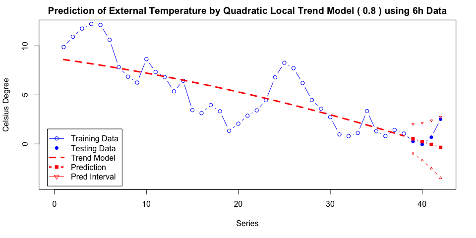

```r
lines(n_trendL_2_6h + vec_l_trendL_2_6h, mat_intervaPred_trendL_2_6h$vec_boundLow,
      type = "b", col = 'red', lwd = 1, lty = 1, pch = 2, cex= 0.5)
legend("bottomleft", inset = .02, legend = c("Training Data", "Testing Data", "Trend Model",
                                             "Prediction", "Pred Interval"),
       col = c("blue", "blue", "red", "red", "red"), pch = c(1, 16, NA, 15, 6),
       lty = c(1, 1, 2, 3, 1), lwd = c(1, 1, 3, 3, 1))
```

# Question 4

Trend Component of Solar Irradiation

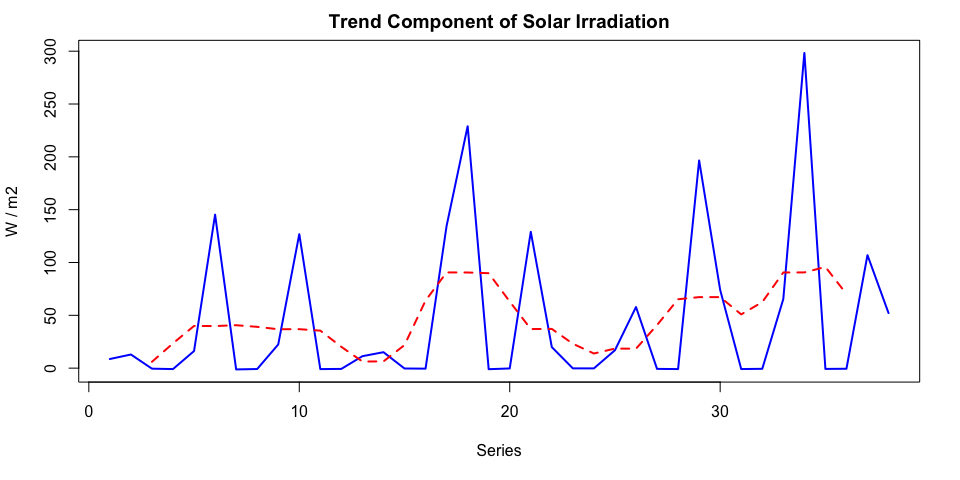

```r
library(forecast)
ts_trend_iSolar = ma(dat.f_6h$iSolar[1: n_6h], order = 4, centre = T)
plot(dat.f_6h$series[1: n_6h], dat.f_6h$iSolar[1: n_6h], type = "l", col = "blue", lty = 1, lwd = 2,
     main = "Trend Component of Solar Irradiation", xlab = "Series", ylab = "W / m2")
lines(dat.f_6h$series[1: n_6h], ts_trend_iSolar, col = "red", lty = 2, lwd = 2)
```

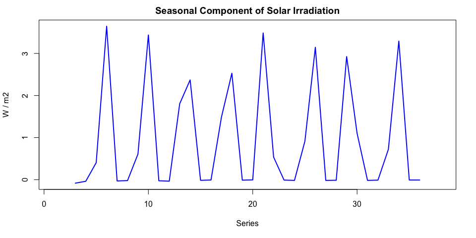

```r
ts_detrend_iSolar = dat.f_6h$iSolar[1: n_6h] / ts_trend_iSolar
plot(dat.f_6h$series[1: n_6h], ts_detrend_iSolar, type = "l", col = "blue", lty = 1, lwd = 2,
     main = "Seasonal Component of Solar Irradiation", xlab = "Series", ylab = "W / m2")
```

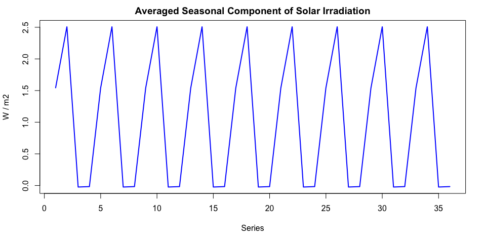

```r
mat_iSolar = t(matrix(data = ts_detrend_iSolar, nrow = 4))
vec_season_iSolar = colMeans(mat_iSolar, na.rm = T)
plot(rep(vec_season_iSolar, 9), type = "l", col = "blue", lty = 1, lwd = 2,
     main = "Averaged Seasonal Component of Solar Irradiation", xlab = "Series", ylab = "W / m2")
```

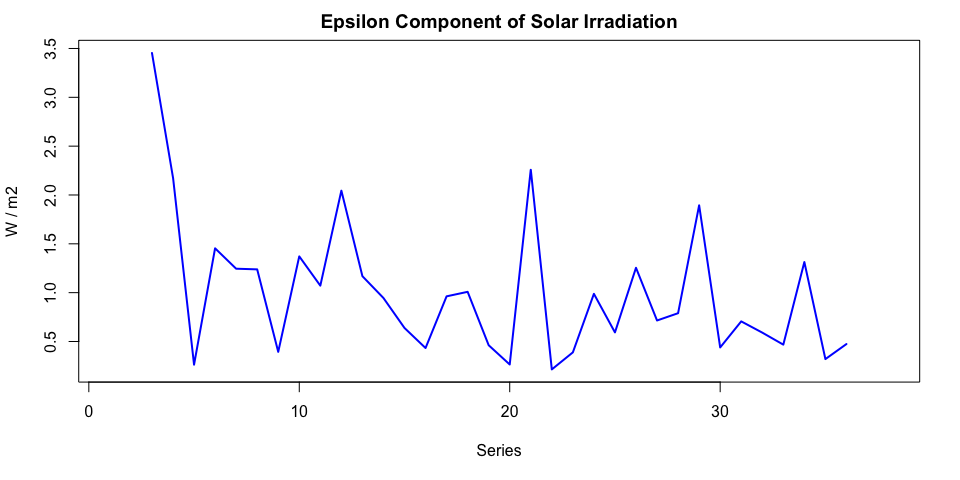

```r
ts_epsilon_iSolar = dat.f_6h$iSolar[1: n_6h] / (ts_trend_iSolar * vec_season_iSolar)
plot(ts_epsilon_iSolar, type = "l", col = "blue", lty = 1, lwd = 2,
     main = "Epsilon Component of Solar Irradiation", xlab = "Series", ylab = "W / m2")
```

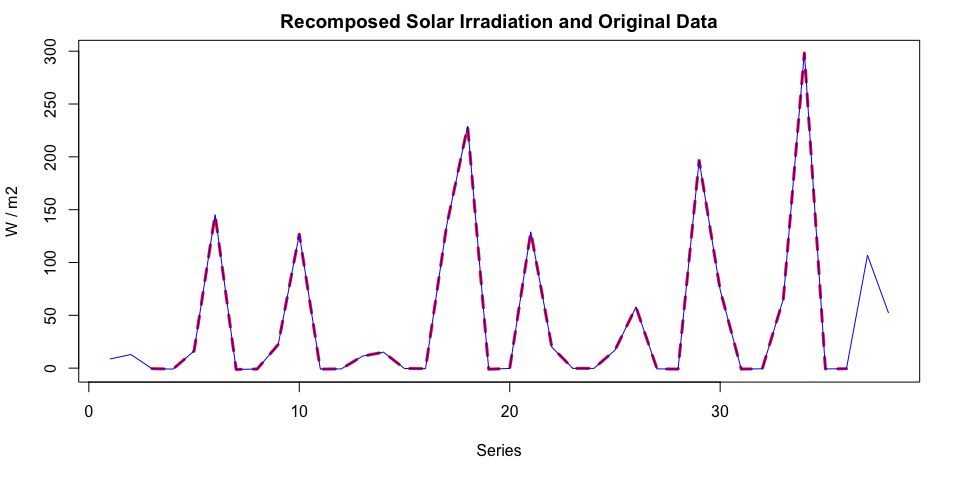

```r
ts_recomposed_iSolar = ts_trend_iSolar * vec_season_iSolar * ts_epsilon_iSolar
plot(dat.f_6h$series[1: n_6h], ts_recomposed_iSolar, type = "l", col = "red", lty = 2, lwd = 3,
     main = "Recomposed Solar Irradiation and Original Data", xlab = "Series", ylab = "W / m2")
lines(dat.f_6h$series[1: n_6h], dat.f_6h$iSolar[1: n_6h], col = "blue", lty = 1, lwd = 1)
```

Predict the solar irradiation in the last day

```r
n_trendL_3_6h <- n_6h - 4
lambda_trendL_3_6h <- 0.8
mat_capSigma_trendL_3_6h <- do_mat_capSigma_trend(lambda = lambda_trendL_3_6h, n = n_trendL_3_6h)
vec_y_trendL_3_6h <- as.numeric(ts_trend_iSolar)[3: 36]
seq_zdi_trendL_3_6h <- do_seq_zeroDecreaseRev(n_trendL_3_6h)
mat_x_trendL_3_6h <- cbind(1, seq_zdi_trendL_3_6h, seq_zdi_trendL_3_6h^2 / 2)
vec_theta.hat_trendL_3_6h <- cal_vec_theta.hat_trend(mat_x_trend = mat_x_trendL_3_6h,
                                                     mat_capSigma_trend = mat_capSigma_trendL_3_6h,
                                                     vec_y_trend = vec_y_trendL_3_6h)
sigma.hat_trendL_3_6h <- cal_sigma.hat(mat_x = mat_x_trendL_3_6h,
                                       vec_y = vec_y_trendL_3_6h,
                                       vec_theta.hat = vec_theta.hat_trendL_3_6h,
                                       mat_capSigma = mat_capSigma_trendL_3_6h)
mat_var.theta.hat_trendL_3_6h <- cal_mat_var.theta.hat(mat_x = mat_x_trendL_3_6h,
                                                       sigma.hat = sigma.hat_trendL_3_6h,
                                                       mat_capSigma = mat_capSigma_trendL_3_6h)
```

```r
vec_y.hat_trendL_3_6h <- mat_x_trendL_3_6h %*% vec_theta.hat_trendL_3_6h
```

```r
vec_l_trendL_3_6h <- c(3, 4, 5, 6)
vec_y.pred_trendL_3_6h <- pred_vec_y_trend_quadratic(vec_l = vec_l_trendL_3_6h,
                                                     vec_theta.hat_trend = vec_theta.hat_trendL_3_6h)
vec_y.pred_trendL_3_6h[1] <- vec_y.pred_trendL_3_6h[1] * vec_season_iSolar[3]
vec_y.pred_trendL_3_6h[2] <- vec_y.pred_trendL_3_6h[2] * vec_season_iSolar[4]
vec_y.pred_trendL_3_6h[3] <- vec_y.pred_trendL_3_6h[3] * vec_season_iSolar[1]
vec_y.pred_trendL_3_6h[4] <- vec_y.pred_trendL_3_6h[4] * vec_season_iSolar[2]
vec_var.pred_trendL_3_6h <- pred_vec_var_trend_quadratic(vec_l = vec_l_trendL_3_6h,
                                                         mat_x_trend = mat_x_trendL_3_6h,
                                                         mat_capSigma_trend = mat_capSigma_trendL_3_6h,
                                                         vec_y.pred_trend = vec_y.pred_trendL_3_6h,
                                                         vec_theta.hat_trend = vec_theta.hat_trendL_3_6h)
mat_intervaPred_trendL_3_6h <- cal_mat_intervalPred(vec_l = vec_l_trendL_3_6h,
                                                    prob = 0.95,
                                                    n = n_trendL_3_6h,
                                                    p = length(vec_theta.hat_trendL_3_6h),
                                                    vec_y.hat = vec_y.pred_trendL_3_6h,
                                                    vec_var = vec_var.pred_trendL_3_6h)
mat_intervaPred_trendL_3_6h$vec_boundUp[1] <- mat_intervaPred_trendL_3_6h$vec_boundUp[1] * vec_season_iSolar[3]
mat_intervaPred_trendL_3_6h$vec_boundUp[2] <- mat_intervaPred_trendL_3_6h$vec_boundUp[2] * vec_season_iSolar[4]
mat_intervaPred_trendL_3_6h$vec_boundUp[3] <- mat_intervaPred_trendL_3_6h$vec_boundUp[3] * vec_season_iSolar[1]
mat_intervaPred_trendL_3_6h$vec_boundUp[4] <- mat_intervaPred_trendL_3_6h$vec_boundUp[4] * vec_season_iSolar[2]
mat_intervaPred_trendL_3_6h$vec_boundLow[1] <- mat_intervaPred_trendL_3_6h$vec_boundLow[1] * vec_season_iSolar[3]
mat_intervaPred_trendL_3_6h$vec_boundLow[2] <- mat_intervaPred_trendL_3_6h$vec_boundLow[2] * vec_season_iSolar[4]
mat_intervaPred_trendL_3_6h$vec_boundLow[3] <- mat_intervaPred_trendL_3_6h$vec_boundLow[3] * vec_season_iSolar[1]
mat_intervaPred_trendL_3_6h$vec_boundLow[4] <- mat_intervaPred_trendL_3_6h$vec_boundLow[4] * vec_season_iSolar[2]
```

```r
plot(dat.f_6h$series[1:n_6h], dat.f_6h$iSolar[1:n_6h],
     type = "b", col = "blue", lwd = 1, lty = 1, xlim = c(0, 42), ylim = c(0, 400),
     main = paste("Prediction of Solar Irradiation by Seasonal Local Trend Model (", lambda_trendL_3_6h,
                  ") using 6h-sampling Data"),
     xlab = "Series", ylab = "Celsius Degree")
lines(dat.f_6h$series[(n_6h+1):(n_6h+4)], dat.f_6h$iSolar[(n_6h+1):(n_6h+4)],
      type = "b", col = "blue", lwd = 1, lty = 1, pch = 16)
```

```r
lines(dat.f_6h$series[(n_6h):(n_6h+1)], dat.f_6h$iSolar[(n_6h):(n_6h+1)],
      type = "c", col = "blue", lwd = 1, lty = 1)
# Plot the Validation Result
lines(dat.f_6h$series[3: (n_6h-2)], vec_y.hat_trendL_3_6h,
      type = "l", col = "red", lty = 2, lwd = 3)
```

```r
# lines(ts_trend_iSolar * vec_season_iSolar, col = 'red', lty = 3, lwd = 2)
# Plot the prediction Result
lines(2 + n_trendL_3_6h + vec_l_trendL_3_6h, vec_y.pred_trendL_3_6h,
      type = "b", col = "red", pch = 15, lty = 3, lwd = 3)
points(2 + n_trendL_3_6h + vec_l_trendL_3_6h, mat_intervaPred_trendL_3_6h$vec_boundUp, col = 'red', pch = 6, cex= 0.5)
```

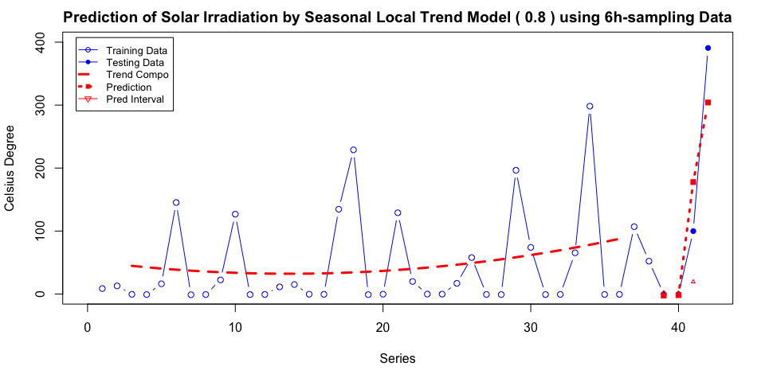

```r
points(2 + n_trendL_3_6h + vec_l_trendL_3_6h, mat_intervaPred_trendL_3_6h$vec_boundLow, col = 'red', pch = 2, cex= 0.5)
legend("topleft", inset = .02, legend = c("Training Data", "Testing Data", "Trend Compo", "Prediction", "Pred Interval"),
       col = c("blue", "blue", "red", "red", "red"), pch = c(1, 16, NA, 15, 6),
       lty = c(1, 1, 2, 3, 1), lwd = c(1, 1, 3, 3, 1), cex = 0.8)
```

Predict the observations for the last day (test data) of the spatial heating based on the 6h data. For this, use the estimated model in question 1.2 and the outdoor temperature from question 1.3.

```r
mat_x.pred_2_6h <- cbind(rep(1, 4), vec_y.pred_trendL_2_6h, vec_y.pred_trendL_3_6h)
vec_y.pred_2_6h  <- mat_x.pred_2_6h %*% vec_theta.hat_expDecay_6h
```

```r
plot(dat.f_6h$series[1:(n_6h)], dat.f_6h$heating[1:(n_6h)],
     type = "b", col = "blue", lwd = 1, lty = 1, xlim = c(0, 42),
     main = "Predicted Heating in the last Day using 6h Data", xlab = "Series", ylab = "W")
lines(dat.f_6h$series[(n_6h+1):(n_6h+4)], dat.f_6h$heating[(n_6h+1):(n_6h+4)],
      type = "b", col = "blue", lty = 1, pch = 16)
```

```r
lines(dat.f_6h$series[(n_6h):(n_6h+1)], dat.f_6h$heating[(n_6h):(n_6h+1)],
      type = "c", col = "blue", lty = 1)
legend("topleft", inset = .02, legend = c("Training Data", "Testing Data", "Prediction"), col = c("blue", "blue", "red"),
       pch = c(1, 16, 15), lty = c(1, 1, 3), lwd = c(1, 1, 2), cex = 0.8)
```

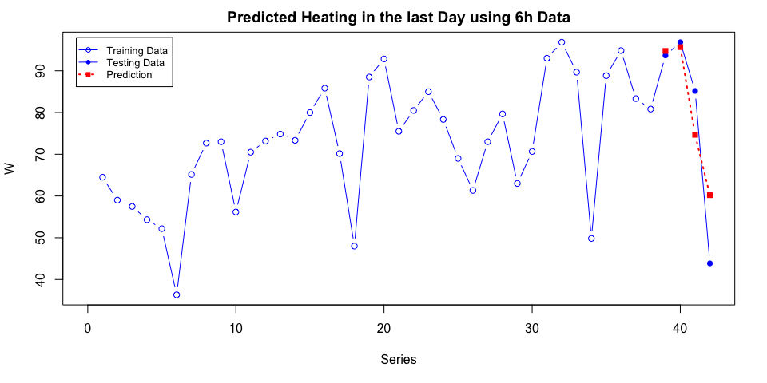

```r
# Plot the prediction result
lines(dat.f_6h$series[(n_6h+1):(n_6h+4)], vec_y.pred_2_6h,
      type = "b", col = "red", pch = 15, lty = 3, lwd = 2)
```